# Reassessment of Analyse a Spatial Network

2024-08-03

# Is there more frequent online car-hailing traffic between communities that have similar racial compositions?

# 1 Introduction

The topic of this report is inspired by Jennifer Candipan’s 2021 publication “From Residence to Movement: The Nature of Racial Segregation in Everyday Urban Mobility.” The article explores how racial segregation manifests in everyday urban mobility: even in racially mixed areas, people’s daily movement patterns may reflect underlying racial segregation. For instance, they analyzed the paths people take from their residential areas to their workplaces and found that even in seemingly integrated communities, individuals of different racial backgrounds tend to use transportation routes and areas that align more closely with their racial identities.

So it is more of a “simplification” of the aforementioned article:

Is Online car-hailing traffic between communities with similar racial compositions more frequent?

Specifically, during off-peak hours, is it common for residents to take ride-hailing services to communities with similar racial demographics, or is the taxi flow between communities positively correlated with the similarity in their racial composition? To address this hypothesis, I used datasets of New York City, including:

- 2020-12 High Volume For-Hire Vehicle Trip Records (parquet file): including trip data from high-volume for-hire vehicle bases (meaning Uber, Lyft, Via, and Juno), community livery bases, luxury limousine bases, and black car bases.
- 2020 Demographics by Neighborhood Tabulation Area (pdf file): including data on the total population of New York City in 2020, including the proportion of races, the proportion of people aged 65 and above, etc., according to the NTAs.
- Taxi Zones (shp file): divided based on NTAs, but are not exactly the same as NTAs.
- 2020 Neighborhood Tabulation Areas (shp file)

The reason for selecting December 2020 is that New York was experiencing a severe phase of the pandemic during this period, which helps to isolate the impact of racial similarity for more accurate modeling. As mentioned in the 2019 study by Bozhao Li, Zhongliang Cai, et al., temporal factors (such as weekdays vs. weekends and day vs. night) significantly influence taxi demand, making peak hour travel more complex. Therefore, my selected time intervals are off-peak hours (10:00-16:00, 20:00-06:00) and weekends. The following output shows the column names of all datasets:

```r
library(sf)
library(dplyr)
library(lubridate)
library(knitr)
library(data.table)
library(MASS)
library(ggplot2)
library(visreg)
```

```r
fhvhv_tripdata <- read.csv("fhvhv_tripdata_2020-12.csv")
ntas_population_data <- read.csv("nyc_ntas_population.csv")

# Read Shapefile files quietly
taxi_zones <- st_read("taxi_zones/taxi_zones.shp", quiet = TRUE)
ntas_zones <- st_read("ntas_zones/geo_export_c37cbe6f-a3c4-4455-8993-dca8f13c97f1.shp", quiet = TRUE)

# Print column names of all datasets
print_colnames <- function(dataset, name) {
  cat(paste("\nColumn names -", name, ":\n"))
  print(colnames(dataset))
}

print_colnames(fhvhv_tripdata, "FHVHV Trip Data")
```

```
##
## Column names - FHVHV Trip Data :
##  [1] "hvfhs_license_num"    "dispatching_base_num" "originating_base_num"
##  [4] "request_datetime"     "on_scene_datetime"    "pickup_datetime"
##  [7] "dropoff_datetime"     "PULocationID"         "DOLocationID"
## [10] "trip_miles"           "trip_time"            "base_passenger_fare"
## [13] "tolls"                "bcf"                  "sales_tax"
## [16] "congestion_surcharge" "airport_fee"          "tips"
## [19] "driver_pay"           "shared_request_flag"  "shared_match_flag"
## [22] "access_a_ride_flag"   "wav_request_flag"     "wav_match_flag"
```

```r
print_colnames(ntas_population_data, "NTAs Population Data")
```

```
##
## Column names - NTAs Population Data :
##  [1] "NTA_Code"                       "Boro_Name"
##  [3] "NTA_Name"                       "Total_population"
##  [5] "X65._Population"                "Percent_65."
##  [7] "Percent_65._Below_poverty"      "Percent_Hispanic_Latino"
##  [9] "Percent_White"                  "Percent_Black_African_American"
## [11] "Percent_Asian"                  "Percent_Other"
```

```r
print_colnames(taxi_zones, "Taxi Zones")
```

```
##
## Column names - Taxi Zones :
## [1] "OBJECTID"   "Shape_Leng" "Shape_Area" "zone"       "LocationID"
## [6] "borough"    "geometry"
```

```r
print_colnames(ntas_zones, "NTAs Zones")
```

```
##
## Column names - NTAs Zones :
## [1] "boro_code"  "boro_name"  "county_fip" "ntacode"    "ntaname"
## [6] "shape_area" "shape_leng" "geometry"
```

# 2 Data preparation

## 2.1 Spatial Data Linkage: Area-weighted Interpolation

Now the data can be divided into two parts:

- High Volume For-Hire Vehicle Trip Data: 2020-12 High Volume For-Hire Vehicle Trip Records (FHV Data), Taxi Zones
- Demographic data: 2020 Demographics by Neighborhood Tabulation Area, 2020 Neighborhood Tabulation Areas

It can be observed that the population data is aggregated by NTAs, whereas the FHV Data is aggregated by Taxi Zones. Because the spatial units of these two datasets do not perfectly align, it is impossible to directly link these datasets using the zone IDs.

To analyze these datasets within the same spatial reference framework, I use Area-weighted Interpolation to interpolate the population data from NTAs to Taxi Zones. This method distributes the data from the source areas (NTAs) to the target areas (Taxi Zones) based on the proportion of overlapping areas, thereby preserving the population distribution characteristics of the source areas to the greatest extent possible and ensuring spatial consistency of the data in the target areas.

The steps are as follows (referencing the tutorial by Christopher Prener published in 2022: https://cran.r-project.org/web/packages/areal/vignettes/areal-weighted-interpolation.html):

### 2.1.1 Check coordinate system consistency and geometry for errors

Ensure that the NTAs and Taxi zones share the same coordinate system, and check and repair geometry to prevent errors during spatial operations.

```r
ntas_zones <- st_transform(ntas_zones, st_crs(taxi_zones))

# Check and fix geometries
ntas_zones <- ntas_zones[!is.na(st_geometry(ntas_zones)), ]
taxi_zones <- taxi_zones[!is.na(st_geometry(taxi_zones)), ]
ntas_zones <- st_make_valid(ntas_zones)
taxi_zones <- st_make_valid(taxi_zones)

# Calculate intersection
intersections <- st_intersection(ntas_zones, taxi_zones)

# Check intersection results
if (nrow(intersections) == 0) {
  stop("No intersection records found, please check the geometries and coordinate systems of the input data.")
}

# Calculate area
intersections$intersection_area <- as.numeric(st_area(intersections))

ntas_zones$total_area <- as.numeric(st_area(ntas_zones))

# Check area calculations
if (any(is.na(intersections$intersection_area))) {
  stop("Failed to calculate intersection area, please check the geometries of the input data.")
}
if (any(is.na(ntas_zones$total_area))) {
  stop("Failed to calculate total area, please check the geometries of the input data.")
}
```

### 2.1.2 Preprocessing of spatial data and calculation of spatial interpolation

Next, the population data is merged with the spatial intersections and weights are calculated based on the ratio of the intersection area to the total area of the NTA:

$$w_{ij} = \frac{A_{\text{intersection}_{ij}}}{A_{\text{NTA}_i}}$$

$$P_{\text{TaxiZone}_j} = \sum_{i} w_{ij} \times P_{\text{NTA}_i}$$
(where $w_{ij}$ represents the weight between the $i$-th NTA and the $j$-th taxi zone.)

After handling any missing values in the weights or population data, the calculated weights were applied to interpolate the population data from the NTA to the taxi zones.

```r
# Convert sf objects to data frames for merging
ntas_zones_df <- as.data.frame(ntas_zones)
intersections_df <- as.data.frame(intersections)

# Merge total_area from ntas_zones to intersections
intersections_df <- merge(intersections_df, ntas_zones_df[, c("ntacode", "total_area")], by = "ntacode")

# Check area calculations
if (any(is.na(intersections_df$total_area))) {
  stop("Failed to merge total area, please check the geometries of the input data.")
}

# Convert intersections_df back to sf object
intersections <- st_as_sf(intersections_df, sf_column_name = "geometry")

# Merge population data
intersections <- merge(intersections, ntas_population_data, by.x = "ntacode", by.y = "NTA_Code", all.x = TRUE)

# Check merge results
missing_pop_data <- sum(is.na(intersections$Total_population))
print(paste("Number of records with missing population data:", missing_pop_data))
```

```
## [1] "Number of records with missing population data: 16"
```

```r
# Calculate weight
intersections$weight <- intersections$intersection_area / intersections$total_area

# Handle NA values in weight
weight_na_count <- sum(is.na(intersections$weight))
print(paste("NAs in weight:", weight_na_count))
```

```
## [1] "NAs in weight: 0"
```

```r
if (weight_na_count > 0) {
  weight_median <- median(intersections$weight, na.rm = TRUE)
  intersections$weight[is.na(intersections$weight)] <- weight_median
  print(paste("Filled NAs in weight with median:", weight_median))
}
intersections$weight <- as.numeric(intersections$weight)

# Handle population data columns
cols_to_interpolate <- c("Total_population", "X65._Population", "Percent_Hispanic_Latino", "Percent_White", "Percent_Black_African_American", "Percent_Asian", "Percent_Other")

for (col in cols_to_interpolate) {
  na_count <- sum(is.na(intersections[[col]]))
  print(paste("NAs in", col, ":", na_count))

  if (na_count > 0) {
    col_median <- median(intersections[[col]], na.rm = TRUE)
    intersections[[col]][is.na(intersections[[col]])] <- col_median
  }

  intersections[[col]] <- as.numeric(intersections[[col]])
}
```

[output not shown]

```r
# Perform interpolation calculations
print("Performing interpolation calculations")
```

```
## [1] "Performing interpolation calculations"
```

```r
for (col in cols_to_interpolate) {
  new_col <- paste0(col, "_weighted")
  tryCatch({
    intersections[[new_col]] <- intersections[[col]] * intersections$weight
  }, error = function(e) {
  })
}
```

### 2.1.3 Integrate and export results

```r
# Aggregate to taxi_zone level
taxi_zone_population <- intersections %>%
  group_by(LocationID) %>%
  summarize(
    Total_population = sum(Total_population_weighted, na.rm = TRUE),
    `65+_Population` = sum(X65._Population_weighted, na.rm = TRUE),
    Percent_Hispanic_Latino = sum(Percent_Hispanic_Latino_weighted, na.rm = TRUE),
    Percent_White = sum(Percent_White_weighted, na.rm = TRUE),
    Percent_Black_African_American = sum(Percent_Black_African_American_weighted, na.rm = TRUE),
    Percent_Asian = sum(Percent_Asian_weighted, na.rm = TRUE),
    Percent_Other = sum(Percent_Other_weighted, na.rm = TRUE)
  )

# Check object type
print(class(taxi_zone_population))
```

```
## [1] "sf"         "tbl_df"     "tbl"        "data.frame"
```

```r
# If it's an sf object, drop the geometry column
if ("sf" %in% class(taxi_zone_population)) {
  taxi_zone_population <- st_drop_geometry(taxi_zone_population)
}

# Check object type again
print(class(taxi_zone_population))
```

```
## [1] "tbl_df"     "tbl"        "data.frame"
```

```r
# Ensure all columns are numeric
taxi_zone_population <- taxi_zone_population %>%
  mutate(across(everything(), as.numeric))

# Check and handle NA values
for (col in names(taxi_zone_population)) {
  na_count <- sum(is.na(taxi_zone_population[[col]]))
  if (na_count > 0) {
    print(paste("Found", na_count, "NAs in", col))
    # For percentage columns, fill NAs with 0; for population columns, fill NAs with median
    if (startsWith(col, "Percent_")) {
      taxi_zone_population[[col]][is.na(taxi_zone_population[[col]])] <- 0
    } else {
      col_median <- median(taxi_zone_population[[col]], na.rm = TRUE)
      taxi_zone_population[[col]][is.na(taxi_zone_population[[col]])] <- col_median
    }
    print(paste("Filled NAs in", col))
  }
}

# Recalculate percentages
percentage_cols <- c("Percent_Hispanic_Latino", "Percent_White", "Percent_Black_African_American", "Percent_Asian", "Percent_Other")
row_sums <- rowSums(taxi_zone_population[percentage_cols], na.rm = TRUE)
taxi_zone_population[percentage_cols] <- taxi_zone_population[percentage_cols] / row_sums * 100

# Handle possible division by zero cases
taxi_zone_population[percentage_cols][is.na(taxi_zone_population[percentage_cols])] <- 0

print("Percentage calculations completed")
```

```
## [1] "Percentage calculations completed"
```

```r
# Merge results back into the original taxi_zones data
taxi_zones <- merge(taxi_zones, taxi_zone_population, by = "LocationID")

# Check results
original_total_pop <- sum(ntas_population_data$Total_population, na.rm = TRUE)
interpolated_total_pop <- sum(taxi_zone_population$Total_population, na.rm = TRUE)

print(paste("Original total population:", original_total_pop))
```

```
## [1] "Original total population: 8443713"
```

```r
print(paste("Interpolated total population:", interpolated_total_pop))
```

```
## [1] "Interpolated total population: 8521408.81993785"
```

```r
print(paste("Difference:", original_total_pop - interpolated_total_pop))
```

```
## [1] "Difference: -77695.8199378513"
```

```r
print(paste("Percentage difference:", (original_total_pop - interpolated_total_pop) / original_total_pop * 100, "%"))
```

```
## [1] "Percentage difference: -0.920161781171995 %"
```

```r
print("Spatial interpolation completed!")
```

```
## [1] "Spatial interpolation completed!"
```

### 2.1.4 Check spatial interpolation results

It can be seen that the Woodside area in ntas_population_data and taxi_zones has basically consistent data, indicating that the spatial interpolation has been successfully completed.

```r
woodside_taxi_zones <- taxi_zones %>% filter(grepl("Woodside", zone, ignore.case = TRUE))
woodside_ntas_population <- ntas_population_data %>% filter(grepl("Woodside", NTA_Name, ignore.case = TRUE))

print("Taxi Zones with 'Woodside' in the zone field:")
```

```
## [1] "Taxi Zones with 'Woodside' in the zone field:"
```

```r
print(woodside_taxi_zones)
```

```
## Simple feature collection with 2 features and 13 fields
## Geometry type: POLYGON
## Dimension:     XY
## Bounding box:  xmin: 1006688 ymin: 204310.6 xmax: 1013752 ymax: 218882.6
## Projected CRS: NAD83 / New York Long Island (ftUS)
##   LocationID OBJECTID Shape_Leng   Shape_Area                             zone
## 1        207      207 0.02837568 4.472308e-05 Saint Michaels Cemetery/Woodside
## 2        260      260 0.13351415 4.223453e-04                         Woodside
##   borough Total_population 65+_Population Percent_Hispanic_Latino Percent_White
## 1  Queens         2.844393      0.7754737                43.99681      45.29721
## 2  Queens     43843.638485   6896.6922630                34.29507      23.63665
##   Percent_Black_African_American Percent_Asian Percent_Other
## 1                      10.696827   0.008036166   0.001117278
## 2                       1.243904  38.624937130   2.199439727
##                         geometry
## 1 POLYGON ((1011572 216050.2,...
## 2 POLYGON ((1011467 216463, 1...
```

```r
print("NTAs with 'Woodside' in the NTA_Name field:")
```

```
## [1] "NTAs with 'Woodside' in the NTA_Name field:"
```

```r
print(woodside_ntas_population)
```

```
##   NTA_Code Boro_Name NTA_Name Total_population X65._Population Percent_65.
## 1     QN63    Queens Woodside            43841            6896        15.7
##   Percent_65._Below_poverty Percent_Hispanic_Latino Percent_White
## 1                      14.9                    33.8          22.6
##   Percent_Black_African_American Percent_Asian Percent_Other
## 1                            0.8          40.4           2.3
```

## 2.2 Calculate the similarity of community ethnic composition

This step defines a function calculate_similarity_index that takes as input the racial composition of two regions. It will calculate the percentage difference for the five main racial categories (Hispanic/Latino, White, Black/African American, Asian, Other).

It is calculated by adding the absolute value of the percentage difference for each racial category, then subtracting this sum from 1 and dividing by 200, so this index ranges from 0 to 1, and high similarity may indicate racial segregation (Jennifer Candipan. 2021). Dividing by 200 is because the maximum difference between two regions is theoretically 200% (for example, one region is 100% white and the other is 100% black). The formula is as follows:

$$SI(A,B) = 1 - \frac{\sum_{i}|P_{A,i} - P_{B,i}|}{200}$$

Where: - SI(A,B) is the racial similarity index between region A and region B

- P_A,i is the percentage of race i in region A
- P_B,i is the percentage of race i in region B
- i represents different racial categories (such as Hispanic/Latino, White, Black/African American, Asian, Other)
- Σ represents the sum of all racial categories

```r
# Make sure taxi_zone_population contains the required percentage column
taxi_zone_population <- taxi_zone_population %>%
  mutate(
    Percent_Hispanic_Latino = Percent_Hispanic_Latino,
    Percent_White = Percent_White,
    Percent_Black_African_American = Percent_Black_African_American,
    Percent_Asian = Percent_Asian,
    Percent_Other = Percent_Other
  )

# Modify the function that calculates the racial similarity index
calculate_similarity_index <- function(zone1_data, zone2_data) {
  races <- c("Percent_Hispanic_Latino", "Percent_White", "Percent_Black_African_American", "Percent_Asian", "Percent_Other")
  sum_diff <- sum(abs(zone1_data[races] - zone2_data[races]))
  return(1 - sum_diff / 200)
}

# Create all possible region pairs
zone_pairs <- expand.grid(zone1 = taxi_zone_population$LocationID, zone2 = taxi_zone_population$LocationID) %>%
  filter(zone1 < zone2)  # Avoid duplication

# Calculate the ethnic similarity index for each pair of regions
zone_pairs$similarity_index <- mapply(function(id1, id2) {
  zone1_data <- taxi_zone_population[taxi_zone_population$LocationID == id1, ]
  zone2_data <- taxi_zone_population[taxi_zone_population$LocationID == id2, ]
  calculate_similarity_index(zone1_data, zone2_data)
}, zone_pairs$zone1, zone_pairs$zone2)
```

## 2.3 Calculate taxi traffic between zones

Here is the translation of the provided steps into English:

This step aims to calculate the core dependent variable for this modeling: inter-regional traffic flow. The independent variable for this modeling is the racial similarity index calculated in the previous steps. The process mainly includes the following steps:

- Filter out off-peak hours: Select time intervals that reflect residents’ autonomous travel choices rather than work commuting needs (weekdays 10:00-16:00, 20:00-06:00, weekends all day).
- Group data by origin and destination: Group the data by the starting point (PULocationID) and the destination (DOLocationID). Each unique origin-destination pair becomes a group. Use summarise(trip_count = n()) to calculate the number of rows in each group, which represents the total number of trips from a specific origin to a specific destination. Finally, ungroup the data to result in a data frame where each row represents a pair of regions (from region A to region B) and the number of trips between them.
- Merge similarity index and flow data: Merge the flow data with the previously created data of all possible region pairs. Set the trip_count of region pairs with no trips (NA values) to 0 to avoid bias that may arise from focusing only on pairs with traffic.

The resulting flow_data created in this step will contain the racial similarity index and actual traffic data, with the actual traffic directly reflecting the intensity of spatial interaction between different regions.

```r
# Convert time columns to datetime format
fhvhv_tripdata$pickup_datetime <- as.POSIXct(fhvhv_tripdata$pickup_datetime)

# Define off-peak hours (weekdays 10:00-16:00, 20:00-06:00, weekends all day)
is_off_peak <- function(datetime) {
  hour <- hour(datetime)
  wday <- wday(datetime)
  (wday %in% 2:6 & (hour >= 10 & hour < 16 | hour >= 20 | hour < 6)) |
  (wday %in% c(1, 7))
}

# Filter data for off-peak hours
off_peak_trips <- fhvhv_tripdata %>%
  filter(is_off_peak(pickup_datetime))

# Count the taxi traffic between each pair of areas
trip_counts <- off_peak_trips %>%
  group_by(PULocationID, DOLocationID) %>%
  summarise(trip_count = n()) %>%
  ungroup()

# Merge similarity index and traffic data
flow_data <- zone_pairs %>%
  left_join(trip_counts, by = c("zone1" = "PULocationID", "zone2" = "DOLocationID")) %>%
  mutate(trip_count = coalesce(trip_count, 0))
```

# 3. Spatial interaction modelling

My hypothesis: Is taxi traffic between communities with similar racial compositions more frequent? This is essentially a spatial interaction problem involving flows between different geographic locations. The gravity model provides an ideal starting point because:

$$T_{ij} = k \cdot \frac{(Pop_i \cdot Pop_j)}{d_{ij}^2}$$

However, the gravity model is not sufficient for my hypothesis due to several limitations:

- It assumes that the effect of distance is fixed (inverse square), which may not be suitable for urban environments. It cannot directly include additional variables, so it cannot control for highly influential variables such as population density.
- It cannot differentiate the weights of the population at the origin and destination, assuming that both have the same influence.

Therefore, for a more flexible estimation using standard regression techniques, I first linearize the model by taking the logarithm, which makes the model easier to estimate and helps handle the skewed distribution that may exist in taxi flow data (Sen & Smith, 1995):

$$\log(T_{ij}) = \log(k) + \log(Pop_i) + \log(Pop_j) - 2\log(d_{ij})$$

Adding coefficients makes the model more flexible:

$$\log(T_{ij}) = \beta_0 + \beta_1 \cdot \log(Pop_i) + \beta_2 \cdot
\log(Pop_j) + \beta_3 \cdot \log(d_{ij})$$

$$T_{ij} \sim NB\left(\exp\left(\beta_0 + \beta_1 \log(Pop_i) + \beta_2
\log(Pop_j) + \beta_3 \log(d_{ij}) + \beta_4 SI_{ij}\right),
\alpha\right)$$

In summary, the above changes to the basic gravity model are all aimed at accurately quantifying the impact of racial similarity on customer flow: taking the logarithm to control for confounding factors (population and distance); adding coefficients to make the model results more interpretable; and making the statistical analysis of discrete data more stable. Also, spatial complexity of cities is not the core issue of my topic. Over-considering spatial complexity may blur my main research question, so GWR is not considered.

## 3.1 Control Variables

The two independent variables, community population and distance from the city center, have a significant impact on passenger flow because of the following two points:

- If population is not controlled, a route that appears to have high traffic due to racial similarity might simply be connecting two large communities.
- If distance is not controlled, low traffic between two racially similar but distant communities could be mistakenly interpreted as a lack of effect of racial similarity.

### 3.1.1 Add regional population data

```r
# Add regional population data
flow_data <- flow_data %>%
  left_join(taxi_zone_population[, c("LocationID", "Total_population")], by = c("zone1" = "LocationID")) %>%
  rename(pop_origin = Total_population) %>%
  left_join(taxi_zone_population[, c("LocationID", "Total_population")], by = c("zone2" = "LocationID")) %>%
  rename(pop_destination = Total_population)
```

### 3.1.2 Calculate the distance between region center points

```r
# Add distance data
# Check if OBJECTID exists and is unique
if("OBJECTID" %in% names(taxi_zones) && length(unique(taxi_zones$OBJECTID)) == nrow(taxi_zones)) {
  taxi_zones$LocationID <- taxi_zones$OBJECTID

  print("LocationID has been successfully overwritten by OBJECTID")
} else {
  print("failed")
}
```

```
## [1] "LocationID has been successfully overwritten by OBJECTID"
```

```r
print(paste("Number of unique values for the new LocationID:", length(unique(taxi_zones$LocationID))))
```

```
## [1] "Number of unique values for the new LocationID: 262"
```

```r
taxi_zones$LocationID <- as.integer(taxi_zones$LocationID)
```

```r
# Ensure that taxi_zones is an sf object
taxi_zones <- st_as_sf(taxi_zones)

# Create a data frame containing centroids
taxi_zones_centroids <- taxi_zones %>%
  mutate(centroid = st_centroid(geometry))

# Distance calculation function
calculate_distance <- function(id1, id2) {
  point1 <- taxi_zones_centroids$centroid[taxi_zones_centroids$LocationID == id1]
  point2 <- taxi_zones_centroids$centroid[taxi_zones_centroids$LocationID == id2]
  if (length(point1) == 0 || length(point2) == 0) {
    return(NA)
  }
  return(as.numeric(st_distance(point1, point2)))
}

# Apply distance calculation
flow_data$distance <- mapply(calculate_distance, flow_data$zone1, flow_data$zone2)

# Check results
summary(flow_data$distance)
```

```
##    Min. 1st Qu.  Median    Mean 3rd Qu.    Max.
##    1132   28848   47051   50325   66837  172011
```

```r
# If the above method still produces issues, we can try using the distance matrix method:

# Create a distance matrix for all zone pairs
all_centroids <- st_centroid(taxi_zones$geometry)
distance_matrix <- st_distance(all_centroids)

# Convert the distance matrix to a data frame
distance_df <- as.data.frame(distance_matrix)
colnames(distance_df) <- taxi_zones$LocationID
rownames(distance_df) <- taxi_zones$LocationID

# Find corresponding distances in flow_data
flow_data$distance <- sapply(1:nrow(flow_data), function(i) {
  as.numeric(distance_df[as.character(flow_data$zone1[i]), as.character(flow_data$zone2[i])])
})

# Check results again
summary(flow_data$distance)
```

```
##    Min. 1st Qu.  Median    Mean 3rd Qu.    Max.
##    1132   28848   47051   50325   66837  172011
```

## 3.2 Modelling result

Use the improved gravity model:

$$T_{ij} \sim NB\left(\exp\left(\beta_0 + \beta_1 \log(Pop_i) + \beta_2
\log(Pop_j) + \beta_3 \log(d_{ij}) + \beta_4 SI_{ij}\right),
\alpha\right)$$

Where: - T_ij is the taxi flow from region i to region j

- Pop_i and Pop_j are the populations of regions i and j respectively
- d_ij is the distance between regions i and j
- SI_ij is the racial similarity index between regions i and j
- β0, β1, β2, β3, β4 are model parameters
- ε_ij is the error term

### 3.2.1 Basic information of modeling results

Model variables:

- trip_count: dependent variable, representing taxi traffic
- log_pop_origin and log_pop_destination: population of origin and destination (logarithm)
- log_distance: distance (logarithm)
- similarity_index: ethnic similarity index

First, looking at the coefficients, the model results show that distance (β3 = -2.337906) and population (β1 = 0.441482, β2 = 0.310056) are indeed important factors influencing ride-hailing traffic flow. The populations at the origin and destination have different degrees of impact on traffic flow, which aligns with the basic assumptions of the gravity model. This also indicates that the modifications to the gravity model effectively capture the differences between the origin and destination. Notably, even after controlling for these basic factors, the racial similarity index (β4 = 0.660046) remains significant, emphasizing the importance of racial factors in explaining traffic patterns.

Model Fit: The comparison of the Null deviance and Residual deviance shows that the full model with all predictor variables significantly improves the explanation of the data. Based on this, we can calculate McFadden’s Pseudo R²:

Pseudo R² = 1 - (Residual deviance / Null deviance) = 1 - (38301 / 115167) ≈ 0.6673

Therefore, the model explains about 66.73% of the original deviance, which is an ideal fit.

Finally, the Theta value of 0.72749 indicates that there is a certain degree of overdispersion in the data, making the use of negative binomial regression appropriate.

```r
model_data <- flow_data %>%
  mutate(
    log_trips = log(trip_count + 1),
    log_pop_origin = log(pop_origin),
    log_pop_destination = log(pop_destination),
    log_distance = log(distance)
  )

model <- glm.nb(trip_count ~ log_pop_origin + log_pop_destination + log_distance + similarity_index,
                data = model_data)

summary(model)
```

```
##
## Call:
## glm.nb(formula = trip_count ~ log_pop_origin + log_pop_destination +
##     log_distance + similarity_index, data = model_data, init.theta = 0.7274939085,
##     link = log)
##
## Coefficients:
##                      Estimate Std. Error z value Pr(>|z|)
## (Intercept)         20.138777   0.123014  163.71   <2e-16 ***
## log_pop_origin       0.441482   0.004228  104.41   <2e-16 ***
## log_pop_destination  0.310056   0.004457   69.57   <2e-16 ***
## log_distance        -2.337906   0.010000 -233.79   <2e-16 ***
## similarity_index     0.660046   0.030408   21.71   <2e-16 ***
## ---
## Signif. codes:  0 '***' 0.001 '**' 0.01 '*' 0.05 '.' 0.1 ' ' 1
##
## (Dispersion parameter for Negative Binomial(0.7275) family taken to be 1)
##
##     Null deviance: 115167  on 33410  degrees of freedom
## Residual deviance:  38301  on 33406  degrees of freedom
## AIC: 272556
##
## Number of Fisher Scoring iterations: 1
##
##
##               Theta:  0.72749
##           Std. Err.:  0.00606
##
##  2 x log-likelihood:  -272543.54000
```

### 3.2.2 Visualizing the relationship between the racial similarity index and taxi traffic

The blue line shows a positive slope, indicating that as racial similarity increases, the predicted taxi traffic flow also increases. However, data points are widely distributed across various levels of racial similarity, suggesting that other unknown factors are also influencing taxi traffic flow. More notably, across the entire range of the racial similarity index (from 0 to 1), there is a very dense horizontal band at the bottom of the y-axis. This indicates that there is a substantial amount of low-frequency travel regardless of racial similarity.

Summarizing the above content, it can be said that although racial similarity may positively influence taxi traffic flow, it is neither the only nor even the primary factor. Based on these results, we can further devise some strategies to explore the phenomena of racial segregation and racial integration in ride-hailing services:

- Compare the predicted traffic flow for different racial combinations
- Build separate models for different races to see if there are differences
- Introduce a new variable representing racial concentration in the community and include an interaction term with this variable in the model
- …

These strategies are still proposed with the aim of more “pure” modeling, as isolating other influencing factors on ride-hailing traffic flow is quite challenging. Focusing more on racial aspects can help us mitigate these unknown influencing factors, as behaviors, manners, and habits tend to be more consistent among people of the same race (Bozhao Li, Zhongliang Cai, et al, 2019).

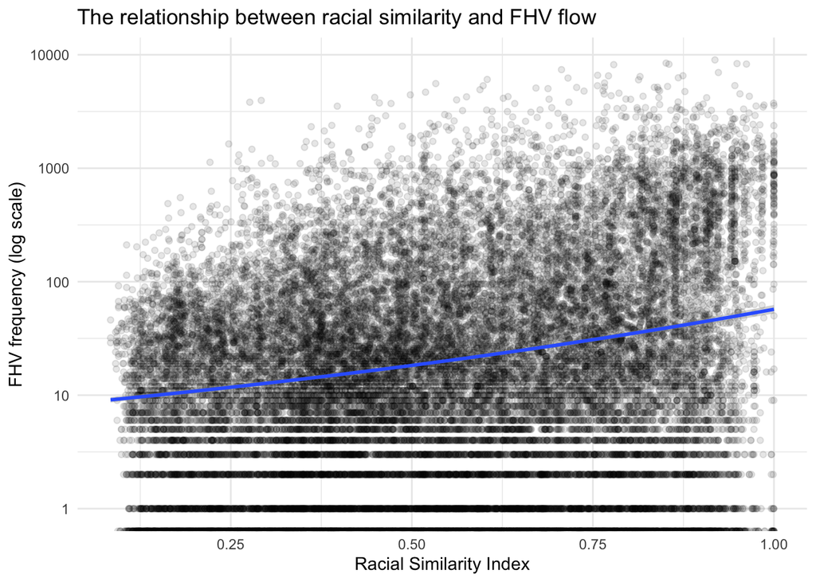

```r
ggplot(model_data, aes(x = similarity_index, y = trip_count)) +
  geom_point(alpha = 0.1) +
  geom_smooth(method = "glm", method.args = list(family = "poisson"), se = TRUE) +
  scale_y_log10() +
  labs(x = "Racial Similarity Index", y = "FHV frequency (log scale)",
       title = "The relationship between racial similarity and FHV flow") +
  theme_minimal()
```

### 3.2.3 Relationship between residual and ethnic similarity index

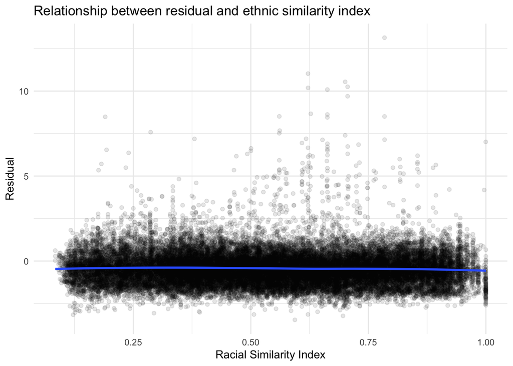

```r
model_data <- model_data %>%
  mutate(residuals = residuals(model))

ggplot(model_data, aes(x = similarity_index, y = residuals)) +
  geom_point(alpha = 0.1) +
  geom_smooth(method = "loess") +
  labs(x = "Racial Similarity Index", y = "Residual",
       title = "Relationship between residual and ethnic similarity index") +
  theme_minimal()
```

## 3.3 Interaction Effect

After knowing that racial similarity has a positive impact on online ride-hailing passenger flow, I want to know how such an effect is distributed spatially. This section will test this by adding an interaction term between racial similarity and distance:

- Modify the model to add the interaction term log_distance:similarity_index
- Examine the impact of racial similarity at different distance ranges

```r
summary(model_data$log_distance)
```

```
##    Min. 1st Qu.  Median    Mean 3rd Qu.    Max.
##   7.032  10.270  10.759  10.629  11.110  12.055
```

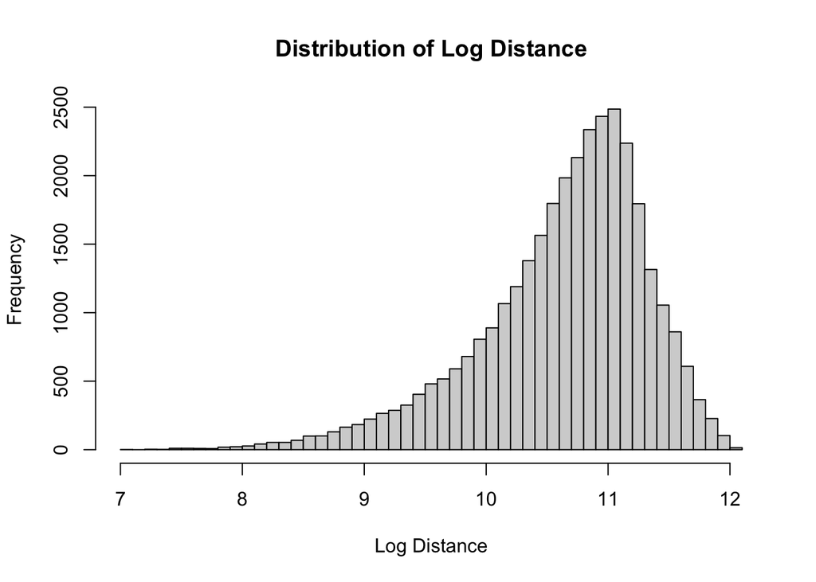

```r
hist(model_data$log_distance, breaks = 50, main = "Distribution of Log Distance", xlab = "Log Distance")
```

```r
quantiles <- quantile(model_data$log_distance, probs = seq(0, 1, 1/7))

model_data$distance_category <- cut(model_data$log_distance,
                                    breaks = quantiles,
                                    labels = c("Very Short", "Short", "Medium-Short",
                                               "Medium", "Medium-Long", "Long", "Very Long"),
                                    include.lowest = TRUE)
table(model_data$distance_category)
```

```
##
##   Very Short        Short Medium-Short       Medium  Medium-Long         Long
##         4773         4773         4773         4773         4773         4773
##    Very Long
##         4773
```

```r
distance_summary <- aggregate(exp(log_distance) ~ distance_category, data = model_data,
                              FUN = function(x) c(min = min(x), max = max(x), mean = mean(x)))
print(distance_summary)
```

```
##   distance_category exp(log_distance).min exp(log_distance).max
## 1        Very Short              1132.505             19935.597
## 2             Short             19938.200             31571.890
## 3      Medium-Short             31584.457             41987.049
## 4            Medium             41988.436             52284.684
## 5       Medium-Long             52285.916             63645.169
## 6              Long             63645.439             79531.073
## 7         Very Long             79535.927            172010.623
##   exp(log_distance).mean
## 1              12534.755
## 2              25927.527
## 3              36852.858
## 4              47111.986
## 5              57847.830
## 6              70749.936
## 7             101248.983
```

```r
actual_breaks <- exp(quantiles)

distance_labels <- paste0(
  c("Very Short (", "Short (", "Medium-Short (", "Medium (", "Medium-Long (", "Long (", "Very Long ("),
  round(actual_breaks[-length(actual_breaks)]/1000, 2),
  "-",
  round(actual_breaks[-1]/1000, 2),
  "km)"
)

model_data$distance_category_detailed <- cut(model_data$log_distance,
                                             breaks = quantiles,
                                             labels = distance_labels,
                                             include.lowest = TRUE)

table(model_data$distance_category_detailed)
```

```
##
##    Very Short (1.13-19.94km)        Short (19.94-31.58km)
##                         4773                         4773
## Medium-Short (31.58-41.99km)       Medium (41.99-52.29km)
##                         4773                         4773
##  Medium-Long (52.29-63.65km)         Long (63.65-79.53km)
##                         4773                         4773
##   Very Long (79.53-172.01km)
##                         4773
```

Based on the above, I divide the distance into seven categories (just for detailed observation).

```r
model_by_distance <- glm.nb(trip_count ~ log_pop_origin + log_pop_destination +
    similarity_index * distance_category,
    data = model_data)

summary(model_by_distance)
```

```
##
## Call:
## glm.nb(formula = trip_count ~ log_pop_origin + log_pop_destination +
##     similarity_index * distance_category, data = model_data,
##     init.theta = 0.7202675512, link = log)
##
## Coefficients:
##                                                 Estimate Std. Error z value
## (Intercept)                                    -2.855740   0.083766 -34.092
## log_pop_origin                                  0.443635   0.004235 104.766
## log_pop_destination                             0.319027   0.004497  70.944
## similarity_index                                1.916086   0.083483  22.952
## distance_categoryShort                         -1.050976   0.075628 -13.897
## distance_categoryMedium-Short                  -1.474194   0.073446 -20.072
## distance_categoryMedium                        -1.865934   0.074413 -25.075
## distance_categoryMedium-Long                   -2.731558   0.075727 -36.071
## distance_categoryLong                          -3.268570   0.075833 -43.102
## distance_categoryVery Long                     -5.173258   0.079593 -64.996
## similarity_index:distance_categoryShort        -0.621303   0.114748  -5.415
## similarity_index:distance_categoryMedium-Short -1.277292   0.113884 -11.216
## similarity_index:distance_categoryMedium       -1.711948   0.115134 -14.869
## similarity_index:distance_categoryMedium-Long  -1.141139   0.116858  -9.765
## similarity_index:distance_categoryLong         -0.847084   0.116768  -7.254
## similarity_index:distance_categoryVery Long    -0.296724   0.124264  -2.388
##                                                Pr(>|z|)
## (Intercept)                                     < 2e-16 ***
## log_pop_origin                                  < 2e-16 ***
## log_pop_destination                             < 2e-16 ***
## similarity_index                                < 2e-16 ***
## distance_categoryShort                          < 2e-16 ***
## distance_categoryMedium-Short                   < 2e-16 ***
## distance_categoryMedium                         < 2e-16 ***
## distance_categoryMedium-Long                    < 2e-16 ***
## distance_categoryLong                           < 2e-16 ***
## distance_categoryVery Long                      < 2e-16 ***
## similarity_index:distance_categoryShort        6.15e-08 ***
## similarity_index:distance_categoryMedium-Short  < 2e-16 ***
## similarity_index:distance_categoryMedium        < 2e-16 ***
## similarity_index:distance_categoryMedium-Long   < 2e-16 ***
## similarity_index:distance_categoryLong         4.03e-13 ***
## similarity_index:distance_categoryVery Long      0.0169 *
## ---
## Signif. codes:  0 '***' 0.001 '**' 0.01 '*' 0.05 '.' 0.1 ' ' 1
##
## (Dispersion parameter for Negative Binomial(0.7203) family taken to be 1)
##
##     Null deviance: 114129  on 33410  degrees of freedom
## Residual deviance:  38153  on 33395  degrees of freedom
## AIC: 272730
##
## Number of Fisher Scoring iterations: 1
##
##
##               Theta:  0.72027
##           Std. Err.:  0.00597
##
##  2 x log-likelihood:  -272696.16600
```

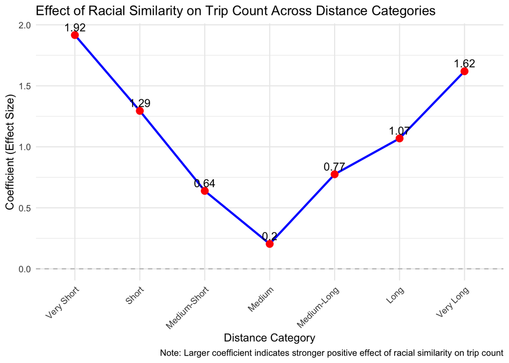

```r
# Extract model coefficients
coef_data <- summary(model_by_distance)$coefficients

# Prepare data
plot_data <- data.frame(
  distance_category = c("Very Short", "Short", "Medium-Short", "Medium", "Medium-Long", "Long", "Very Long"),
  coefficient = c(
    coef_data["similarity_index", "Estimate"],
    coef_data["similarity_index", "Estimate"] + coef_data["similarity_index:distance_categoryShort", "Estimate"],
    coef_data["similarity_index", "Estimate"] + coef_data["similarity_index:distance_categoryMedium-Short", "Estimate"],
    coef_data["similarity_index", "Estimate"] + coef_data["similarity_index:distance_categoryMedium", "Estimate"],
    coef_data["similarity_index", "Estimate"] + coef_data["similarity_index:distance_categoryMedium-Long", "Estimate"],
    coef_data["similarity_index", "Estimate"] + coef_data["similarity_index:distance_categoryLong", "Estimate"],
    coef_data["similarity_index", "Estimate"] + coef_data["similarity_index:distance_categoryVery Long", "Estimate"]
  )
)

# Convert distance categories to factors and specify the order
plot_data$distance_category <- factor(plot_data$distance_category,
                                      levels = c("Very Short", "Short", "Medium-Short", "Medium", "Medium-Long", "Long", "Very Long"))

ggplot(plot_data, aes(x = distance_category, y = coefficient)) +
  geom_line(aes(group = 1), color = "blue", size = 1) +
  geom_point(color = "red", size = 3) +
  theme_minimal() +
  labs(title = "Effect of Racial Similarity on Trip Count Across Distance Categories",
       x = "Distance Category",
       y = "Coefficient (Effect Size)",
       caption = "Note: Larger coefficient indicates stronger positive effect of racial similarity on trip count") +
  theme(axis.text.x = element_text(angle = 45, hjust = 1)) +
  geom_hline(yintercept = 0, linetype = "dashed", color = "gray") +
  annotate("text", x = 1:7, y = plot_data$coefficient,
           label = round(plot_data$coefficient, 2),
           vjust = -0.5, hjust = 0.5, color = "black")
```

In very short and very long travel distances, the impact of racial similarity is strongest. This might indicate:

- At very short distances, the impact of racial similarity is greatest, possibly because people prefer to move within culturally similar environments for their daily short-distance travels.
- At medium distances, the impact of racial similarity is minimal, likely because travel over these distances is more driven by functional needs such as work or shopping, rather than cultural preferences.
- At very long distances, the impact of racial similarity strengthens again, possibly because long-distance travel often involves specific purposes (such as visiting relatives or cultural activities), which may be related to racial and cultural backgrounds.

This complex pattern reveals that the influence of racial similarity on travel behavior is nonlinear and interacts intricately with distance. Therefore, in studying urban traffic patterns, one cannot simply assume a uniform influence of socio-cultural factors but must consider variations across different spatial scales.

# 4. Conclusion and Discussion

## 4.1 Conclusion

The above model can preliminarily verify my hypothesis: Online car-hailing traffic between communities with similar racial compositions is more frequent, and no matter which model, distance is the main factor affecting travel volume. As distance increases, travel volume decreases significantly.

From the first gravity model we can summarize three main points:

- Population and Distance Importance: The model confirms that the population at the origin and destination (β1 = 0.441482 and β2 = 0.310056 respectively) and the distance between them (β3 = -2.337906) significantly affect ride-hailing traffic flow, validating the assumptions of the gravity model.Also the difference in coefficients for origin and destination populations also indicates varying impacts on traffic flow.
- Role of Racial Similarity: The racial similarity index (β4 = 0.660046) is significant, suggesting a positive correlation between racial similarity and taxi traffic flow. This result implies that areas with higher racial similarity may experience more taxi trips, yet the dispersion in the data and dense horizontal bands of low-frequency travel across all levels of similarity clearly show that other factors are also at play.
- Model Fit and Overdispersion: The model explains approximately 66.73% of the variance in traffic flow, as indicated by McFadden’s Pseudo R², demonstrating a good fit. The Theta value (0.72749) highlights the presence of overdispersion, justifying the use of negative binomial regression over simpler Poisson regression.

The visualization results of the first model show that while racial similarity contributes to predicting taxi traffic flow, it is not the sole determinant. Other factors (potentially unmeasured in this model) also influence traffic patterns. Strategies such as comparing traffic flows across different racial combinations or modeling specific races separately could help further isolate and understand these influences.

This is just a preliminary confirmation of their positive correlation. Modeling results show that this positive correlation still has many details to be explored, such as the travel characteristics of a single race, the travel characteristics of communities of the same type, and is affected by many other factors. Moreover, including new variables like racial concentration and examining interaction effects could enhance the model’s explanatory power regarding racial dynamics in ride-hailing services.

Data analysis of the interactive effect model showed that the impact of racial similarity on online ride-hailing traffic was significantly influenced by travel distance. Specifically, the interaction between racial similarity and distance category showed that racial similarity had the strongest impact on both very short (1.13-19.94km) and very long (79.53-172.01km) trips. This suggests that people may prefer short daily commutes in culturally similar areas and make similar choices for long trips that may be driven by social visits or cultural activities. In contrast, the effect of racial similarity is reduced for medium travel distances (41.99-52.29km). This pattern suggests that there is a complex nonlinear relationship between racial similarity and travel behavior, which is influenced by travel purpose and distance, and emphasizes the importance of considering these dynamics when studying urban mobility patterns and planning transportation services.

## 4.2 Discussion

Limitations:

- Using area for spatial interpolation can lead to data distortion, causing the population proportion in communities to be scaled inaccurately.
- The validity of the model needs verification. The accuracy of the optimization model scheme, pieced together from different literature, has not been confirmed, and complementary control experiments are required.
- The relationship between dependent and independent variables is more complex than linear. As seen in the visualization of the first model, the scatter plot is very dispersed, indicating a lack of clear linear characteristics. This may be due to ride-hailing traffic being influenced by many other factors, or it may suggest a non-linear relationship, requiring further model comparisons.

Outlooks:

- The topic of travel behavior cannot be separated from spatiotemporal sequences. However, this report did not consider the lag effect of time and merely counted the ride-hailing traffic. For deeper exploration, time is an indispensable variable to consider.
- In studying the impact of social isolation and social integration on travel behavior, I still find it unclear how to isolate spatial variables from non-spatial variables. The scatter plots of model fitting results remain highly dispersed, indicating that exploring their relationships requires more complex models (beyond linear models).

#### References:

[1] Nelson, R. J. (2023). “The spatial and social logic of the Minibus Taxi network: how access may support social inclusion in Cape Town, South Africa.” Applied Mobilities, 8(1), 1-25. DOI: 10.1080/23800127.2021.1926054 .

[2]Candipan, J. (2021). “From Residence to Movement: The Nature of Racial Segregation in Everyday Urban Mobility.” DOI: 10.1080/01944363.2020.1759126 .

[3]Li, B., et al. (2019). “Exploring urban taxi ridership and local associated factors using GPS data and geographically weighted regression.” Cities, 87, 68-86. DOI: 10.1016/j.cities.2018.12.006 .

[4]Schalekamp, H., and McLachlan, N. (2015). “Minibus-taxi Operator Reforms, Engagement and Attitudes in Cape Town” in Paratransit in African Cities. London, New York: Routledge .

[5] Sen, A. & Smith, T.E. (1995). “Gravity models of spatial interaction behavior.” Springer Science & Business Media.

[6] Fotheringham, A.S. & O’Kelly, M.E. (1989). “Spatial interaction models: formulations and applications.” Kluwer Academic Publishers.

[7] LeSage, J.P. & Pace, R.K. (2008). “Spatial econometric modeling of origin-destination flows.” Journal of Regional Science, 48(5), 941-967.

[8] Simini, F., González, M.C., Maritan, A. & Barabási, A.L. (2012). “A universal model for mobility and migration patterns.” Nature, 484(7392), 96-100.

[9] Ellis, M., Wright, R. & Parks, V. (2004). “Work together, live apart? Geographies of racial and ethnic segregation at home and at work.” Annals of the Association of American Geographers, 94(3), 620-637.

[10] Flowerdew, R. & Aitkin, M. (1982). “A method of fitting the gravity model based on the Poisson distribution.” Journal of Regional Science, 22(2), 191-202.

[11] Oshan, T.M. (2016). “A primer for working with the Spatial Interaction modeling (SpInt) module in the python spatial analysis library (PySAL).” REGION, 3(2), 11-23.